# 16 support for statements in text

Holly Beale

09 May, 2019

# Compendium stats

## revised for V9 public

General URL for all compendia: https://treehousegenomics.soe.ucsc.edu/public-data/

Name of compendium on the website: Compendium v9 Public (March 2019)

Blurb: This compendium was released in March 2019. It includes a total of 11,454 samples from Treehouse (identifiers start with “TH”), TCGA and TARGET projects. This data was generated by library preparation methods including polyA selection.

Clinical data page: https://xenabrowser.net/datapages/?dataset=TreehousePEDv9_clinical_metadata.2019-03-15.tsv&host=https%3A%2F%2Fxena.treehouse.gi.ucsc.edu%3A443

Clinical data link: https://xena.treehouse.gi.ucsc.edu/download/TreehousePEDv9_clinical_metadata.2019-03-15.tsv

### Compendium size

```r
v9_clinical <- read_tsv("https://xena.treehouse.gi.ucsc.edu/download/TreehousePEDv9_clinical_metadata.2019-03-15.tsv")
nrow(v9_clinical)
```

```
## [1] 11454
```

There are 11454 samples in the compendium

## Threshold

```
cat /private/groups/treehouse/archive/compendium/TreehousePEDv9/compendium_info.json | grep mcs_similarity_threshold
```

```
"mcs_similarity_threshold": 0.875,
```

# Seeds used for making subsets

```r
read_counts <- read_tsv("../data/read_counts.txt",
                        col_names = c("sample_id", "measurement", "read_count")) %>%
  mutate(parent_id = gsub("_est.*$", "", sample_id),
         seed = gsub("^.*seed_", "", sample_id))
```

### Not all seeds are unique across the whole experiment

```r
length(unique(read_counts$sample_id))
```

```
## [1] 95
```

```r
length(unique(read_counts$seed))
```

```
## [1] 94
```

### This one is present in two parent samples

```r
bad_seed <- read_counts %>%
  select(parent_id, seed) %>%
  distinct %>%
  mutate(dupe = duplicated(seed)) %>%
  dplyr::filter(dupe) %>%
  pull(seed)

read_counts %>%
  dplyr::filter(seed == bad_seed)
```

```
## # A tibble: 8 x 5
##   sample_id              measurement             read_count parent_id seed
##   <chr>                  <chr>                        <dbl> <chr>     <chr>
## 1 TH_Eval_018_est16M_UM… total_sequences          23395401  TH_Eval_… 2214
## 2 TH_Eval_018_est16M_UM… Uniquely_mapped_read_c…  21407087  TH_Eval_… 2214
## 3 TH_Eval_018_est16M_UM… Uniquely_mapped_non_du…  17087944. TH_Eval_… 2214
## 4 TH_Eval_018_est16M_UM… UMEND                    15987081. TH_Eval_… 2214
## 5 TH_Eval_019_est18M_UM… total_sequences          23806017  TH_Eval_… 2214
## 6 TH_Eval_019_est18M_UM… Uniquely_mapped_read_c…  21619040  TH_Eval_… 2214
## 7 TH_Eval_019_est18M_UM… Uniquely_mapped_non_du…  19341810. TH_Eval_… 2214
## 8 TH_Eval_019_est18M_UM… UMEND                    17994504. TH_Eval_… 2214
```

### All seeds are unique within each parent sample

```r
for (this_parent_id in unique(read_counts$parent_id)) {
  print(this_parent_id)
  these_read_counts = subset(read_counts, parent_id == this_parent_id)
  print(length(unique(these_read_counts$sample_id)))
  print(length(unique(these_read_counts$seed)))
}
```

```
## [1] "TH_Eval_018"
## [1] 19
## [1] 19
## [1] "TH_Eval_015"
## [1] 19
## [1] 19
## [1] "TH_Eval_019"
## [1] 19
## [1] 19
## [1] "TH_Eval_014"
## [1] 19
## [1] 19
## [1] "TH_Eval_016"
## [1] 19
## [1] 19
```

# Duration of pipelines

```r
timestamps_raw <- read_delim("../data/pipeline_timestamps.txt",
                             delim = " ",
                             col_names = c("sample_id",
                                           "pipeline",
                                           "start_stop",
                                           "timestamp",
                                           "deleteme")) %>%
  select(-deleteme)
library(lubridate)
timestamps <- timestamps_raw %>%
  mutate(timestamp = ymd_hms(gsub("T", " ", gsub(",", "", timestamp))),
         start_stop = gsub(":", "", start_stop)) %>%
  spread(start_stop, timestamp)

ts <- timestamps %>%
  mutate(duration = end - start)

read_counts_for_merge <- read_counts %>%
  select(sample_id, parent_id, measurement, read_count) %>%
  spread(measurement, read_count)

ts_anno <- left_join(ts, read_counts_for_merge) %>%
  group_by(pipeline) %>%
  mutate(minimum_pipeline_time = median(as.numeric(duration)[grepl("_est1M", sample_id)]),
         adjusted_duration = as.numeric(duration) - minimum_pipeline_time,
         min_per_M_total_reads = adjusted_duration / (total_sequences / 1e6 - 1),
         min_per_M_UMEND_reads = adjusted_duration / (UMEND / 1e6 - 1))
subsamples_to_select <- read_tsv("../data/evenly_selected_subsamples_with_binwidth_4.tsv")
```

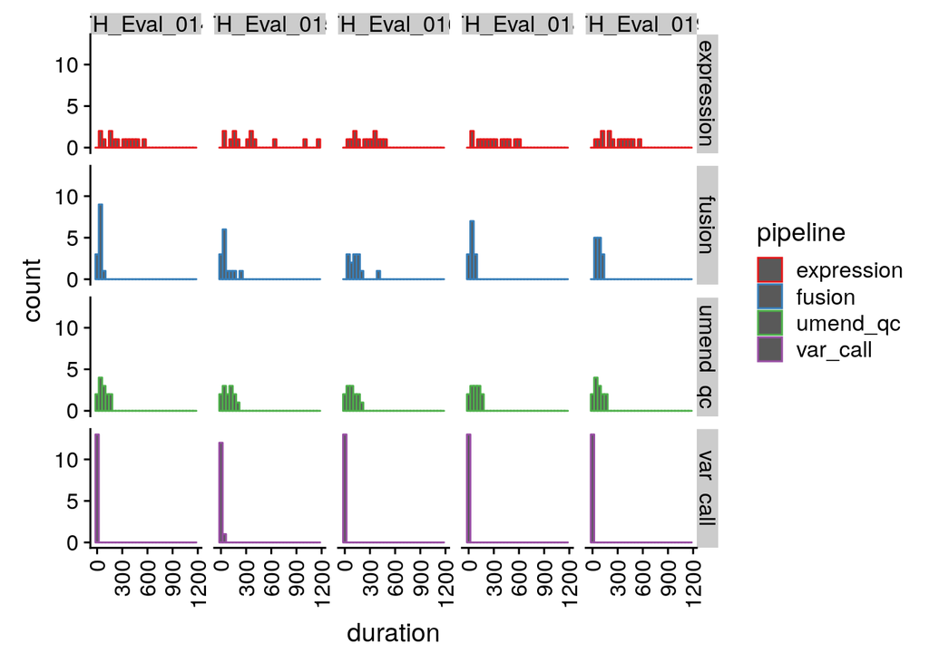

```r
selected_ts_anno <- ts_anno %>% filter(sample_id %in% subsamples_to_select$sample_id)

# how long does each pipeline take?
ggplot(selected_ts_anno) +
  geom_histogram(aes(x = duration, color = pipeline)) +
  facet_grid(pipeline~parent_id) +
  scale_color_brewer(palette = "Set1") +
  theme(axis.text.x = element_text(angle = 90, hjust = 1, vjust = 0.5))
```

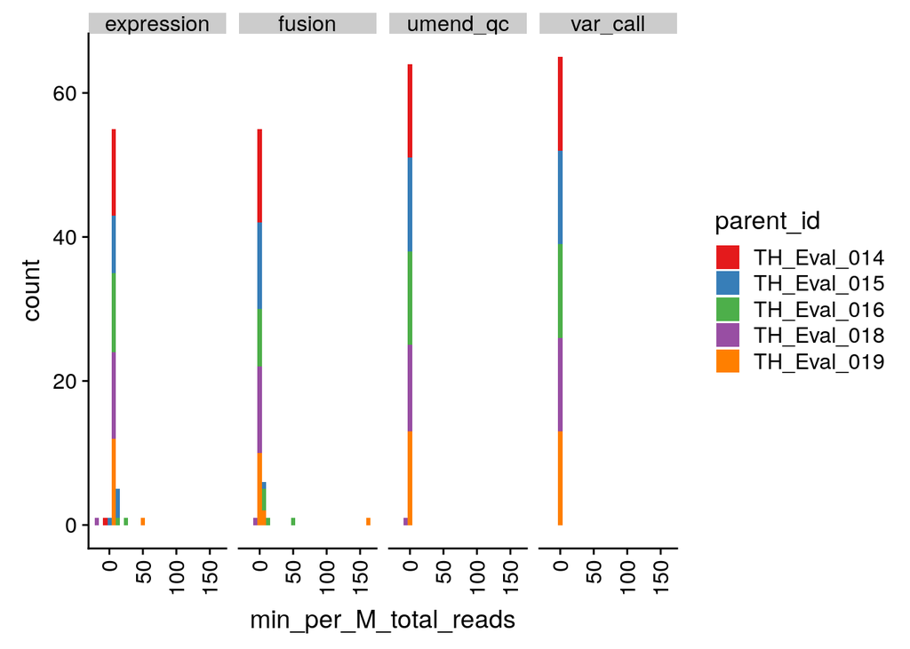

```r
# how variable is the rate per M reads
ggplot(selected_ts_anno) +
  geom_histogram(aes(x = min_per_M_total_reads, fill = parent_id)) +
  facet_grid(~pipeline) +
  scale_fill_brewer(palette = "Set1") +
  theme(axis.text.x = element_text(angle = 90, hjust = 1, vjust = 0.5))
```

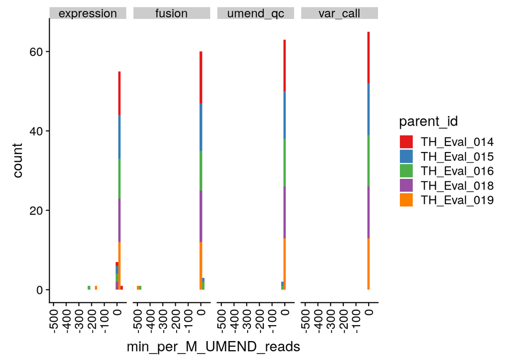

```r
# how variable is the rate per M UMEND reads
ggplot(selected_ts_anno) +
  geom_histogram(aes(x = min_per_M_UMEND_reads, fill = parent_id)) +
  facet_grid(~pipeline) +
  scale_fill_brewer(palette = "Set1") +
  theme(axis.text.x = element_text(angle = 90, hjust = 1, vjust = 0.5))
```

```r
ts_summary <- selected_ts_anno %>%
  group_by(pipeline, minimum_pipeline_time) %>%
  summarize(median_min_per_M_total_reads = median(min_per_M_total_reads),
            median_min_per_M_UMEND_reads = median(min_per_M_UMEND_reads),
            sd_min_per_M_total_reads = sd(min_per_M_total_reads),
            sd_min_per_M_UMEND_reads = sd(min_per_M_UMEND_reads)) %>%
  select(pipeline,
         minimum_pipeline_time,
         median_min_per_M_total_reads,
         sd_min_per_M_total_reads,
         median_min_per_M_UMEND_reads,
         sd_min_per_M_UMEND_reads)

minutes_per_expression_sample_base=selected_ts_anno %>%
  dplyr::filter(pipeline == "expression") %>%
  pull(minimum_pipeline_time) %>%
  unique %>%
  round(1)

minutes_per_million_reads_in_expression_sample <- ts_summary %>%
  dplyr::filter(pipeline == "expression") %>%
  pull(median_min_per_M_total_reads) %>%
  unique %>%
  round(1)

minutes_per_qc_sample_base <- selected_ts_anno %>%
  dplyr::filter(pipeline == "umend_qc") %>%
  pull(minimum_pipeline_time) %>%
  unique %>%
  round(1)

minutes_per_million_reads_in_qc_sample <- ts_summary %>%
  dplyr::filter(pipeline == "umend_qc") %>%
  pull(median_min_per_M_total_reads) %>%
  unique %>%
  round(1)

example_total_reads <- 70

estimate_expression_pipeline_duration <-
  (minutes_per_expression_sample_base-minutes_per_million_reads_in_expression_sample) +
  example_total_reads * minutes_per_million_reads_in_expression_sample

estimate_umend_qc_pipeline_duration <-
  (minutes_per_qc_sample_base-minutes_per_million_reads_in_qc_sample) +
  example_total_reads * minutes_per_million_reads_in_qc_sample
```